# Lab 02 - Linear Regression

due Sunday, 9/25 at 11:59pm

# Getting started

## Clone the repo & start new RStudio project

- Go to the Math 218 organization on GitHub (http://www.github.com/math218-fall2022). Click on the repo with the prefix **lab-02-linear-regression-**. It contains the starter documents you need to complete the lab.
- Click on the green **Code** button, select the second option “Open with GitHub Desktop”

[figure not shown]

- The GitHub Desktop application will open up, with a white window that says “Clone a Repository”. **Important**: in the second line that says “Local Path”, there is a button that says `Choose...`. Click on it, and find and select the folder we created for this course. Then hit the blue `Clone` button.

[figure not shown]

- After successfully cloning, the window will disappear and you will see the that Current Repository is the one you just cloned. Success!
- **Note**: if you want to commit and push changes for a different project (e.g. an application exercise), you can switch to the other project by hitting the first top=left button `Current Repository`. You should see all of your cloned projects here. Simply pick the one you would like to commit changes for!

# Packages

Here, we will make use of the package `ggfortify`. Check if it is installed by running

```r
library(ggfortify)
```

If you receive an error message, then run the following command in your Console once:

```r
install.packages("ggfortify")
```

```r
library(tidyverse)
library(MASS)
library(ISLR2)
library(ggfortify)
```

# Simple linear regression

We will begin by working with some data about fish. The data consist of record of seven common different fish species in fish market sales. Our goal will be to estimate the `Weight` (g) of a fish given its other characteristics. We have access to the following predictors: `Species`, `BodyLength` (nose to beginning of tail), `TotalLength` (nose to end of tail), `Height`, and `Width`. All physical measurements are in cm.

```r
fish <- read.csv("data/fish.csv", header = T)
head(fish)
```

```
##   Species Weight BodyLength TotalLength  Height  Width
## 1   Bream    242       23.2        30.0 11.5200 4.0200
## 2   Bream    290       24.0        31.2 12.4800 4.3056
## 3   Bream    340       23.9        31.1 12.3778 4.6961
## 4   Bream    363       26.3        33.5 12.7300 4.4555
## 5   Bream    430       26.5        34.0 12.4440 5.1340
## 6   Bream    450       26.8        34.7 13.6024 4.9274
```

We will begin by using the `lm()` function to fit a simple linear model, with `Weight` and the response and `BodyLength` as the predictor. The `summary()` function gives us estimates, standard errors, and $p$-values for the coefficients, as well as the $R^2$ for the model.

```r
mod0 <- lm(Weight ~ BodyLength, data = fish)
summary(mod0)
```

```
##
## Call:
## lm(formula = Weight ~ BodyLength, data = fish)
##
## Residuals:
##     Min      1Q  Median      3Q     Max
## -414.90  -71.26    6.08   98.31  363.84
##
## Coefficients:
##             Estimate Std. Error t value Pr(>|t|)
## (Intercept) -462.375     32.243  -14.34   <2e-16 ***
## BodyLength    32.792      1.148   28.55   <2e-16 ***
## ---
## Signif. codes:  0 '***' 0.001 '**' 0.01 '*' 0.05 '.' 0.1 ' ' 1
##
## Residual standard error: 144.3 on 157 degrees of freedom
## Multiple R-squared:  0.8385, Adjusted R-squared:  0.8375
## F-statistic: 815.3 on 1 and 157 DF,  p-value: < 2.2e-16
```

We can access just the estimates $\hat{\beta}$ using the `coef()` function, and obtain confidence intervals (default are 95%).

```r
coef(mod0)
```

```
## (Intercept)  BodyLength
##  -462.37508    32.79216
```

```r
confint(mod0)
```

```
##                  2.5 %     97.5 %
## (Intercept) -526.06064 -398.68951
## BodyLength    30.52377   35.06056
```

The `predict()` function can be used to obtain confidence and prediction intervals for the response, for a given value of the predictors:

Compare the widths of the intervals. Why is there a difference?

`fit` is the estimated value, and `lwr` and `upr` give the lower and upper bounds of the 95% intervals, respectively.

```r
predict(mod0, data.frame(BodyLength = c(15, 30, 45)), interval = "confidence")
```

```
##          fit        lwr        upr
## 1   29.50738  -4.578935   63.59369
## 2  521.38984 497.235512  545.54416
## 3 1013.27230 965.100571 1061.44402
```

```r
predict(mod0, data.frame(BodyLength = c(15, 30, 45)), interval = "prediction")
```

```
##          fit       lwr       upr
## 1   29.50738 -257.5550  316.5698
## 2  521.38984  235.3367  807.4429
## 3 1013.27230  724.1989 1302.3457
```

# Diagnostics

Here, I plot the response and predictors, along with the fitted least squares regression line. There is some evidence for non-linearity between `Weight` and `BodyLength`…

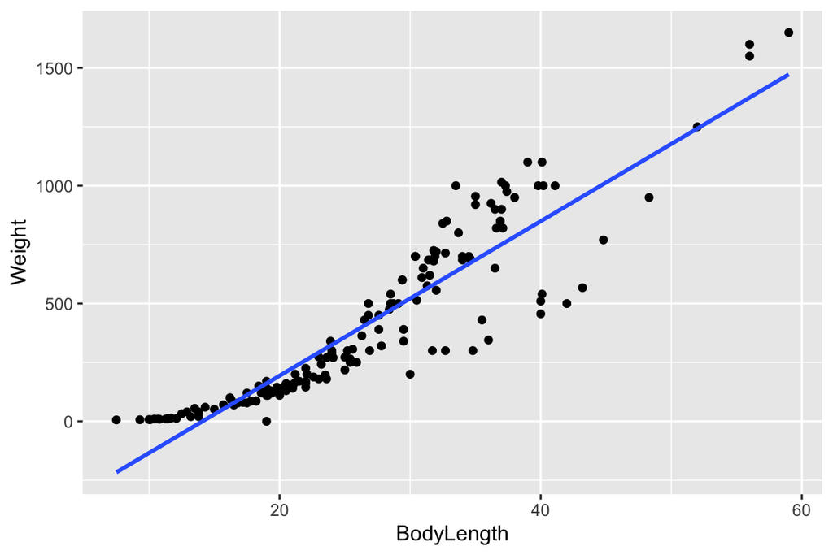

```r
ggplot(fish, aes(x = BodyLength,y = Weight))+
  geom_point() +
  geom_smooth(method = "lm", se = F)
```

We can compute the residuals from a linear regression fit using the `residuals()` function. Once we compute them, we can plot them! The following code also provides a horizontal line at 0 as a point of reference. It is clear the the assumption of linearity is violated.

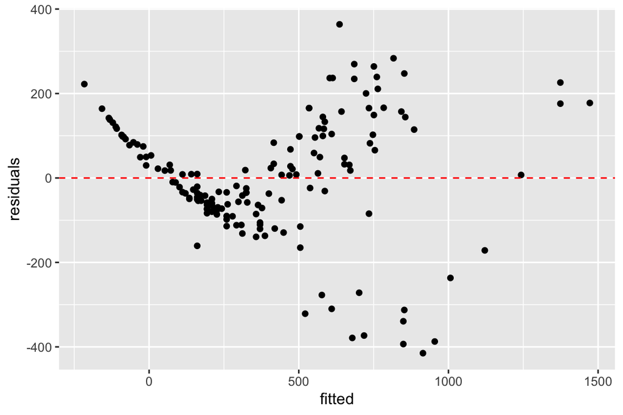

```r
resids <- residuals(mod0)
data.frame(fitted = predict(mod0), residuals = resids) %>%
  ggplot(., aes(x = fitted, y = residuals))+
  geom_point() +
  geom_hline(yintercept = 0, linetype = "dashed", col = "red")
```

Leverage statistics can be computed using the `hatvalues()` function. Also, recall that the average leverage is calculated as $(p+1)/n$. The following code obtains the leverage of each point, as well as the average leverage:

```r
lev <- hatvalues(mod0)
p <- 1
n <- nrow(fish)
av_lev <- (p+1)/n
```

Here, I plot the leverage in the order of data collection, with a reference for the average leverage:

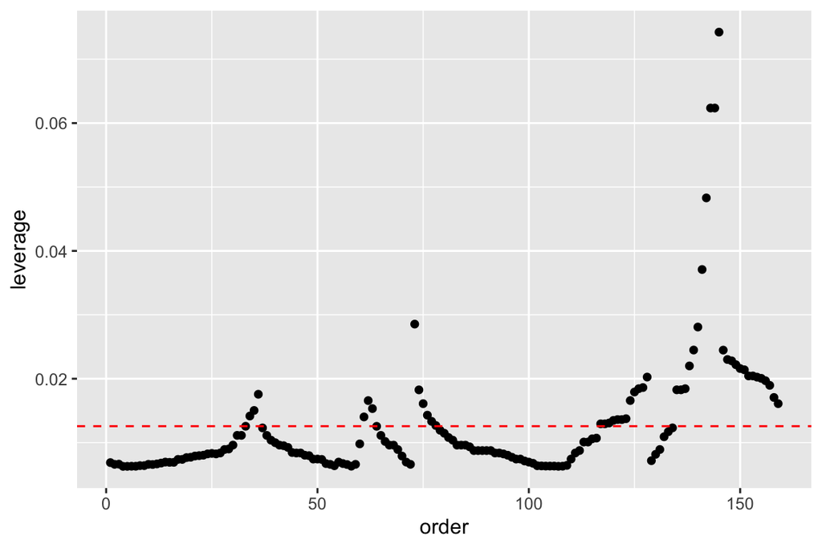

```r
data.frame(leverage = lev) %>%
  mutate(order = row_number()) %>%
  ggplot(., aes(x = order, y = leverage)) +
  geom_point() +
  geom_hline(yintercept = av_lev, col = "red", linetype = "dashed")
```

Alternatively, we can take advantage of the `autoplot()` function from the `ggfortify` library we loaded. We pass in a fitted `lm()` object, and `autoplot()` will plot up to six diagnostic plots. Here, we will focus on four: residuals vs fitted, Normal q-q plot, standardized residuals vs fitted, and residuals vs leverage. Notice that `autoplot` will provide the indices of points of interest (possible outliers or high leverage) in the respective plots.

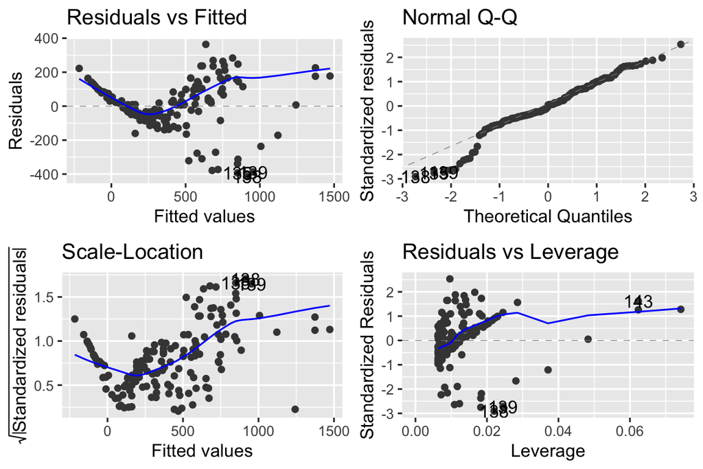

```r
autoplot(mod0, which = c(1,2,3,5))
```

# Multiple linear regression

In order to fit a multiple linear regression model using least squares, we again use the `lm()` function. The `summary()` function now outputs the regression coefficients for all the predictors.

This is a bad example of naming models…oops! Usually we would want to have more informative variable names.

```r
mod1 <- lm(Weight ~ BodyLength + Height, data = fish)
summary(mod1)
```

```
##
## Call:
## lm(formula = Weight ~ BodyLength + Height, data = fish)
##
## Residuals:
##     Min      1Q  Median      3Q     Max
## -285.18  -76.00  -23.33   70.02  378.91
##
## Coefficients:
##             Estimate Std. Error t value Pr(>|t|)
## (Intercept) -502.589     28.903 -17.389  < 2e-16 ***
## BodyLength    27.213      1.292  21.059  < 2e-16 ***
## Height        20.805      3.014   6.903 1.21e-10 ***
## ---
## Signif. codes:  0 '***' 0.001 '**' 0.01 '*' 0.05 '.' 0.1 ' ' 1
##
## Residual standard error: 126.7 on 156 degrees of freedom
## Multiple R-squared:  0.8763, Adjusted R-squared:  0.8747
## F-statistic: 552.6 on 2 and 156 DF,  p-value: < 2.2e-16
```

Suppose I want to fit a multiple linear regression model using all the quantitative predictors. Rather than type them all out, I can use shorthand. On the right side of the `~`, typing a period `.` will tell `R` to use all the variables in the specified dataset (minus the specified response). Because I am currently only interested in the quantitative predictors, I will add `- Species` to tell `R` to use all the predictors *except* for `Species`.

```r
mod2 <- lm(Weight ~ . - Species, data = fish)
summary(mod2)
```

```
##
## Call:
## lm(formula = Weight ~ . - Species, data = fish)
##
## Residuals:
##     Min      1Q  Median      3Q     Max
## -242.89  -65.84  -24.36   57.61  446.05
##
## Coefficients:
##             Estimate Std. Error t value Pr(>|t|)
## (Intercept) -500.131     29.274 -17.085  < 2e-16 ***
## BodyLength    56.738     17.969   3.157  0.00192 **
## TotalLength  -30.130     15.799  -1.907  0.05837 .
## Height        28.455      8.643   3.292  0.00123 **
## Width         21.476     19.286   1.114  0.26720
## ---
## Signif. codes:  0 '***' 0.001 '**' 0.01 '*' 0.05 '.' 0.1 ' ' 1
##
## Residual standard error: 122.8 on 154 degrees of freedom
## Multiple R-squared:  0.8853, Adjusted R-squared:  0.8823
## F-statistic: 297.1 on 4 and 154 DF,  p-value: < 2.2e-16
```

## Interactions

It is easy to include interaction terms in a linear model using the `lm()` function. The syntax `BodyLength:Height` tells `R` to include an interaction term between the two predictors. We can also use `*` as shorthand:

```r
# these two models are equivalent!
int_mod <- lm(Weight ~ BodyLength + Height + BodyLength:Height, data = fish)
int_mod <- lm(Weight ~ BodyLength * Height, data = fish)
summary(int_mod)
```

```
##
## Call:
## lm(formula = Weight ~ BodyLength * Height, data = fish)
##
## Residuals:
##      Min       1Q   Median       3Q      Max
## -217.547  -26.796    4.796   30.205  281.505
##
## Coefficients:
##                   Estimate Std. Error t value Pr(>|t|)
## (Intercept)        44.5793    39.1676   1.138   0.2568
## BodyLength          4.2491     1.6671   2.549   0.0118 *
## Height            -61.2548     5.5445 -11.048   <2e-16 ***
## BodyLength:Height   3.0209     0.1921  15.728   <2e-16 ***
## ---
## Signif. codes:  0 '***' 0.001 '**' 0.01 '*' 0.05 '.' 0.1 ' ' 1
##
## Residual standard error: 78.89 on 155 degrees of freedom
## Multiple R-squared:  0.9524, Adjusted R-squared:  0.9514
## F-statistic:  1033 on 3 and 155 DF,  p-value: < 2.2e-16
```

Let’s visualize what this interaction implies about the model fit. In the following code, I am generating estimates of $\color{blue}{\text{weight}}$ from the model for a range of $\color{blue}{\text{height}}$ values, at three different, fixed values of $\color{blue}{\text{BodyLength}}$. Then we plot them. Notice how the relationship between $\color{blue}{\text{height}}$ and $\color{blue}{\text{weight}}$ really changes at different values of $\color{blue}{\text{BodyLength}}$!

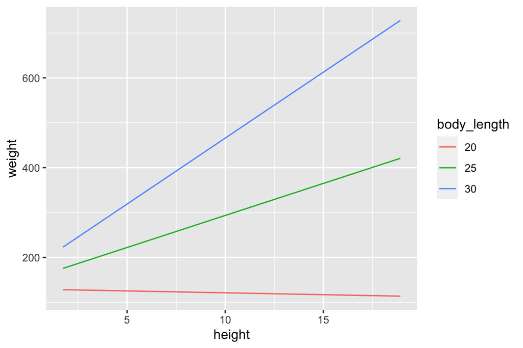

```r
beta_hat <- coef(int_mod) # obtain estimated coefficients

# create a sequence of height values that align with the observed data
height_seq <- seq(min(fish$Height), max(fish$Height), 0.1)

# fix body length to be 30
body_length1 <- 30

# generate predictions at the different height values and the fixed body length
y_pred1 <- beta_hat[1] + beta_hat[2]*body_length1 + beta_hat[3]*height_seq +
  beta_hat[4]*body_length1*height_seq

# store into data frame
df1 <- data.frame(height = height_seq, body_length = body_length1, weight = y_pred1)

# repeat for body length fixed at 25
body_length2 <- 25
y_pred2 <- beta_hat[1] + beta_hat[2]*body_length2 + beta_hat[3]*height_seq +
  beta_hat[4]*body_length2*height_seq
df2 <- data.frame(height = height_seq, body_length = body_length2, weight = y_pred2)

# repeat for body length fixed at 20
body_length3 <- 20
y_pred3 <- beta_hat[1] + beta_hat[2]*body_length3 + beta_hat[3]*height_seq +
  beta_hat[4]*body_length3*height_seq
df3 <- data.frame(height = height_seq, body_length = body_length3, weight = y_pred3)

rbind(df1, df2, df3) %>%
  mutate(body_length = factor(body_length)) %>%
  ggplot(., aes(x = height, y = weight, col = body_length)) +
  geom_line()
```

## Non-linear transformations of predictors

Given a predictor $X$, we can create a predictor $X^{k}$ using `I(X^k)`. The function `I()` is necessary because the carat `^` has a special meaning in R. The following regresses `Weight` on `BodyLength` and `BodyLength^2`.

```r
mod_poly <- lm(Weight ~ BodyLength + I(BodyLength^2), data = fish)
summary(mod_poly)
```

```
##
## Call:
## lm(formula = Weight ~ BodyLength + I(BodyLength^2), data = fish)
##
## Residuals:
##     Min      1Q  Median      3Q     Max
## -428.27  -62.07   -2.54   75.17  384.55
##
## Coefficients:
##                   Estimate Std. Error t value Pr(>|t|)
## (Intercept)     -289.30816   66.26665  -4.366 2.30e-05 ***
## BodyLength        19.19473    4.71697   4.069 7.47e-05 ***
## I(BodyLength^2)    0.23322    0.07859   2.968  0.00347 **
## ---
## Signif. codes:  0 '***' 0.001 '**' 0.01 '*' 0.05 '.' 0.1 ' ' 1
##
## Residual standard error: 140.8 on 156 degrees of freedom
## Multiple R-squared:  0.8472, Adjusted R-squared:  0.8452
## F-statistic: 432.3 on 2 and 156 DF,  p-value: < 2.2e-16
```

The $p$-value for the quadratic term is significant, and suggests that the quadratic model might be an improvement over the simple linear regression model.

## Qualitative predictors

Now, I will fit a linear regression model using all the predictors, including the qualitative `Species` variable.

What is our baseline level for `Species`?

```r
mod3 <- lm(Weight ~ ., data = fish)
summary(mod3)
```

```
##
## Call:
## lm(formula = Weight ~ ., data = fish)
##
## Residuals:
##     Min      1Q  Median      3Q     Max
## -227.96  -57.50  -14.06   36.46  419.92
##
## Coefficients:
##                  Estimate Std. Error t value Pr(>|t|)
## (Intercept)      -996.103    119.858  -8.311 5.62e-14 ***
## SpeciesParkki     215.837     70.302   3.070  0.00255 **
## SpeciesPerch      239.429    106.098   2.257  0.02549 *
## SpeciesPike      -137.511    129.969  -1.058  0.29177
## SpeciesRoach      148.840     88.070   1.690  0.09313 .
## SpeciesSmelt      507.036    115.011   4.409 1.99e-05 ***
## SpeciesWhitefish  164.431     88.427   1.860  0.06494 .
## BodyLength        -32.794     24.185  -1.356  0.17719
## TotalLength        66.068     22.295   2.963  0.00355 **
## Height              6.530     13.126   0.497  0.61960
## Width              -4.675     23.959  -0.195  0.84557
## ---
## Signif. codes:  0 '***' 0.001 '**' 0.01 '*' 0.05 '.' 0.1 ' ' 1
##
## Residual standard error: 94.48 on 148 degrees of freedom
## Multiple R-squared:  0.9348, Adjusted R-squared:  0.9303
## F-statistic:   212 on 10 and 148 DF,  p-value: < 2.2e-16
```

Looking at a plot of residuals vs fitted values, it is clear that a linear model is still insufficient. However, it appears to be an improvement from the simpler model.

What are some other predictors that you think would be helpful in predicting the `Weight` of these species?

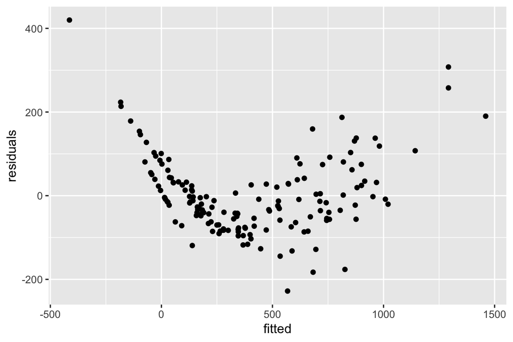

```r
resids <- residuals(mod3)
data.frame(fitted = predict(mod3), residuals = resids) %>%
  ggplot(., aes(x = fitted, y = residuals))+
  geom_point()
```

# Writing functions

We will often be interested in performing an operation for which no function is available. In this case, we may want to write our own functions. As an example, below I am creating a function called `fahrenheit_to_celsius()`, which takes in one parameter as an input. This simple function will convert the passed in argument from degrees fahrenheit to celsius!

Notice that the function name goes on the left, and the generic placeholder for the input is `temp_F`. You could really change this to anything you want, so long as it is consistent throughout the function definition. We can type as many commands between the curly braces as we wish. Right before the closing curly brace, we need to `return()` or output the result of the function.

```r
fahrenheit_to_celsius <- function(temp_F) {
  temp_C <- (temp_F - 32) * 5 / 9
  return(temp_C)
}
```

To call the function, simply pass in a temperature:

What happens if you don’t pass in a parameter?

```r
fahrenheit_to_celsius(32)
```

```
## [1] 0
```

# Normal distribution

A **normal distribution** is a distribution that occurs naturally in many situations. It is a symmetric, bell-shaped curve. The normal distribution is specified by two quantities: a mean parameter $\mu$, and a variance (or standard deviation) $\sigma^2$ ($\sigma$). We say that a variable is distributed as $N(\mu, \sigma^2)$. In the linear regression model, the irreducible error $\epsilon$ is assumed to be distributed as $N(0, \sigma^2)$.

The distribution is centered at $\mu$, and its spread is governed by $\sigma^2$. The larger the $\sigma$, the more spread out the the distribution. The following code uses the `rnorm()` function to generate 1000 random samples from the distributions $N(0,1)$, $N(0, 4)$, and $N(-3, 0.25)$. `rnorm()` expects three arguments as input: the number of random samples you want, the mean $\mu$, and the standard deviation $\sigma$.

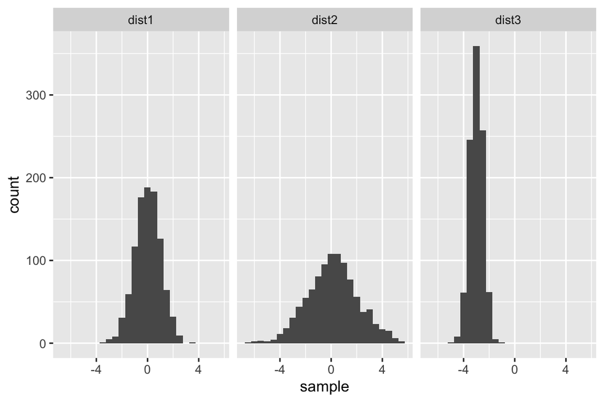

```r
set.seed(5)
dist1 <- rnorm(1000, 0, 1)
dist2 <- rnorm(1000, 0, sqrt(4))
dist3 <- rnorm(1000, -3, sqrt(0.25))
data.frame(dist1,dist2,dist3) %>%
  pivot_longer(., cols = 1:3, names_to = "distribution", values_to = "sample") %>%
  ggplot(., aes(x = sample)) +
  geom_histogram(binwidth = 0.5) +
  facet_wrap(~distribution)
```

# Your turn!

## Exercise 1

You will create some simulated data and will fit simple linear regression models to it. Make sure to use `set.seed(2)` prior to starting Exercise 1 to ensure consistent results.

1. Using the `rnorm()` function, create a vector `x` that contains 100 observations drawn from a $N(0,1)$ distribution. This represents a feature or predictor, $X$.

Be careful about variance vs. standard deviation in `rnorm()` !

2. Using the `rnorm()` function, create a vector `eps` that contains 100 observations drawn from a $N(0,0.25)$ distribution – a Normal distribution with mean 0 and variance 0.25.
3. Using `x` and `eps`, generate a vector `y` according to the model

   $$Y = -2 + 0.5X + \epsilon$$

   What is the length of `y`? What are the values of $\beta_{0}$ and $\beta_{1}$?
4. Fit a least squares linear model to predict `y` using `x`. How do $\hat{\beta}_{0}$ and $\hat{\beta}_{1}$ compare to $\beta_{0}$ and $\beta_{1}$?
5. Now fit a polynomial regression model that predicts `y` using `x` and `x^2`. Is there evidence that the quadratic term improves model fit? Explain.
6. Suppose we wanted to generate data with *more* noise. How might we do that? Would you expect the confidence intervals for $\beta_{0}$ and $\beta_{1}$ to be wider, narrower, or about the same as compared to the original data?

This is a good place to pause, knit and **commit changes** with the commit message “Added answer for Ex 1.” Push these changes when you’re done.

## Exercise 2

Here, we explore the *collinearity* problem. Run the following by changing to `eval = T`:

The argument

```
eval
= F
```

in the chunk header tells R to *not* evaluate/run this chunk when knitting.

```r
set.seed(2)
x1 <- runif(100) # this generates data from a Uniform distribution
x2 <- 0.5 * x1 + rnorm(100)/10
y <- 2 + 2*x1 + 0.3*x2 + rnorm(100)
```

1. Write out the form of the linear model (you may use “b” in place of $\beta$). What are the regression coefficients?

Hint: the `cor()` function may be useful

2. What is the correlation between `x1` and `x2`? Create a scatterplot displaying a relationship between the two variables, and comment on what you see.
3. Using this data, fit a least squares regression line to predict `y` using `x1` and `x2`. Describe the results obtained. How do the estimates $\hat{\beta}_{j}$ relate to the true $\beta_{j}$? Can you reject the null hypothesis $H_{0}: \beta_{1} = 0$ or the null hypothesis $H_{0}: \beta_{2} = 0$?
4. Now fit a least squares regression line to predict `y` using only `x1`. Comment on your results. Can you reject the null hypothesis $H_{0}: \beta_{1} = 0$?
5. Now fit a least squares regression line to predict `y` using only `x2`. Comment on your results. Can you reject the null hypothesis $H_{0}: \beta_{2} = 0$?
6. Do the results obtained in (c) - (e) contradict each other? Explain.
7. Now, suppose we obtain one additional observation which happened to be mismeasured. Be sure to run this code by changing `eval = F` to `eval = T` in the `R` chunk header.

```r
set.seed(1)
x1 <- runif(100)
x2 <- 0.5 * x1 + rnorm(100)/10
y <- 2 + 2*x1 + 0.3*x2 + rnorm(100)
x1 <- c(x1, 0.1 )
x2 <- c(x2, 0.8)
y <- c(y, 6)
```

Refit the linear models from (c) - (e) using this new data. What effect does this new observation have on the each of the models? In each model, is this observation an outlier? A high-leverage point? Both? Explain your answers.

This is a good place to pause, knit and **commit changes** with the commit message “Added answer for Ex 2.” Push these changes when you’re done.

## Exercise 3

Create a function called `mse` that takes two vectors, one of true values `true` and one of predicted values `preds`, and returns the mean squared error.

## Exercise 4

Create a function called `dist` that takes in three arguments: the first two arguments are vectors `x1`, `x2` of the same length. The third argument is a boolean value called `euclidean`. When `euclidean = T`, your `dist()` function should return the Euclidean distance between `x1` and `x2`. When `euclidean = F`, your `dist()` function should return the Manhattan distance. The following code should be used somewhere in your function:

```r
if(euclidean == T){
  ## code
} else{
  ## code
}
```

# Submission

Once you are finished, knit one last time, commit your changes, and push to GitHub. Then submit the PDF file to Canvas!